# MATH9102-W9-Assumptions

## Step 2b: Visualize residual distribution

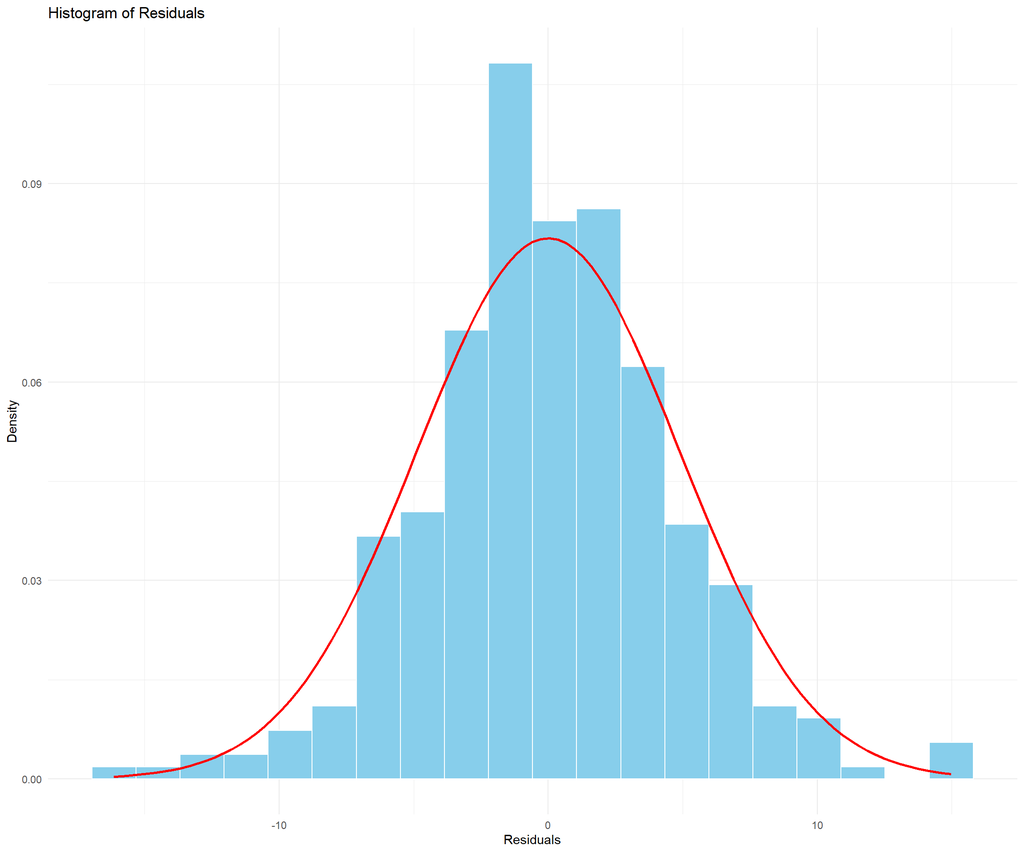

Residual Distribution Plots for Model 3

```r
# Visualize residual distribution


# Histogram of Residuals
ggplot(data.frame(residuals = resid(model3)), aes(x = residuals)) +
  geom_histogram(aes(y = ..density..),
                 bins = 20,
                 fill = "skyblue",
                 color = "white") +
  stat_function(fun = dnorm,
                args = list(mean = mean(resid(model1)), sd = sd(resid(model1))),
                color = "red",
                linewidth = 1) +
  labs(title = "Histogram of Residuals",
       x = "Residuals",
       y = "Density") +
  theme_minimal()
```

```
For confidence bands, please install `qqplotr`.
```

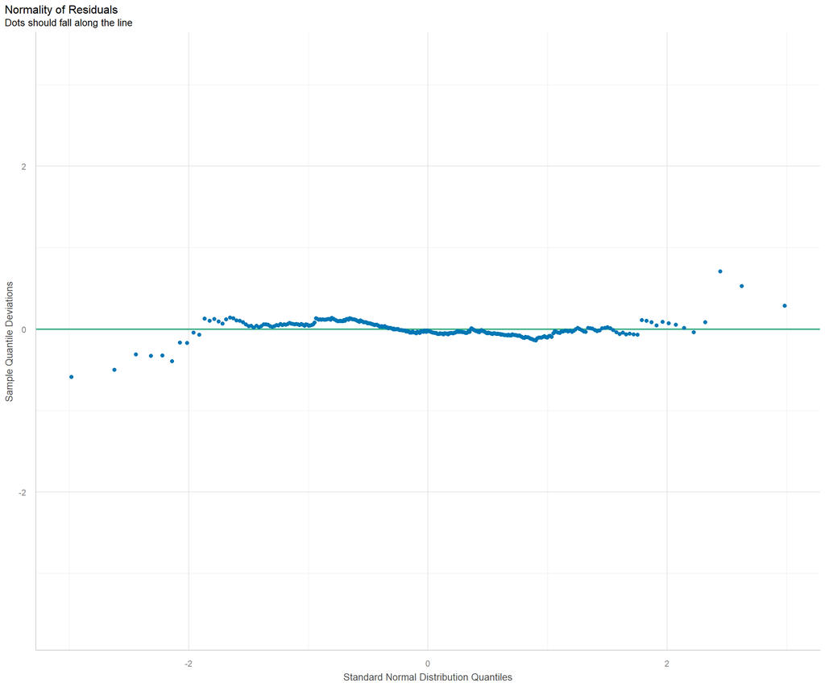

Residual Distribution Plots for Model 3

```r
# A transformed version of a Q–Q plot displayed horizontally
plot(check_normality(model3))
```

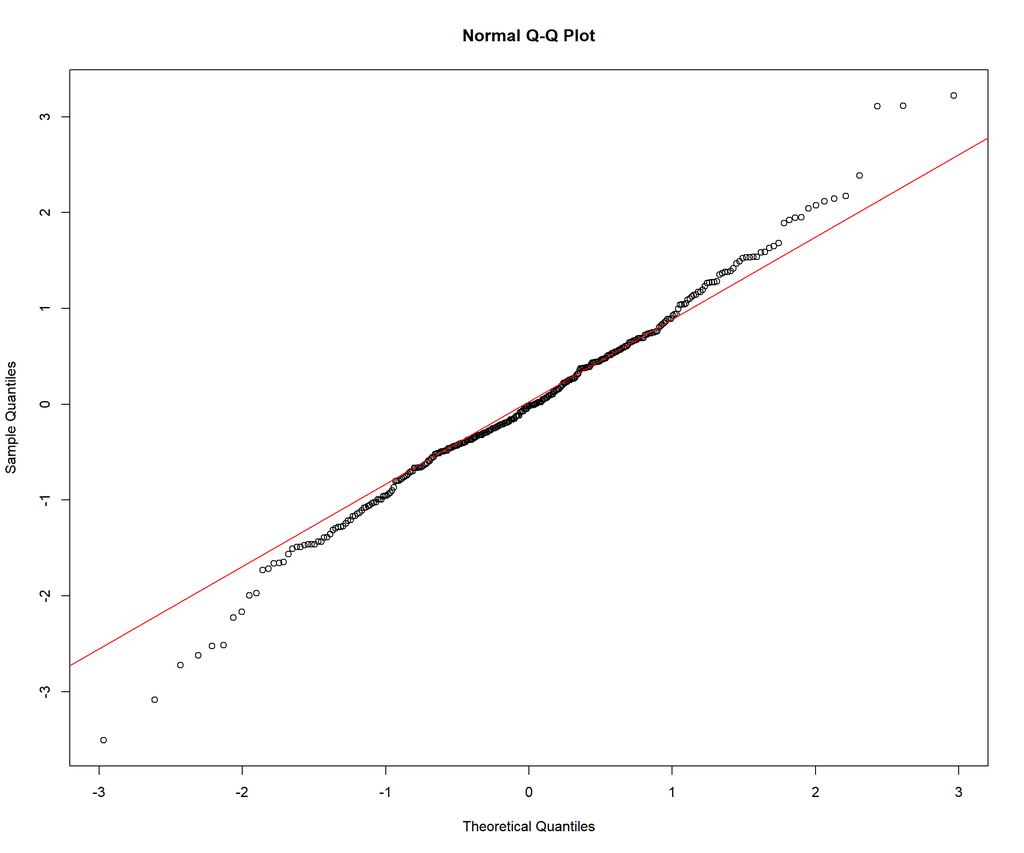

Residual Distribution Plots for Model 3

```r
# Q-Q plot of standardized residuals
qqnorm(rstandard(model3))
qqline(rstandard(model3), col = "red")
```

### Step 2c: Check outliers or influential points

```r
# Check for outliers or influential points

performance::check_outliers(model3)
```

```
OK: No outliers detected.
- Based on the following method and threshold: cook (0.9).
- For variable: (Whole model)
```

### Step 2d: Examine the residuals

```r
# Extract residuals
residuals <- resid(model3)

# Standardize the residuals
std_residuals <- residuals / sd(residuals)

# Calculate max and min of the standardized residuals
max_std_residual <- max(std_residuals)
min_std_residual <- min(std_residuals)

# Print the results
cat("Max standardized residual:", max_std_residual, "\n")
```

```
Max standardized residual: 3.225165
```

```r
cat("Min standardized residual:", min_std_residual, "\n")
```

```
Min standardized residual: -3.474867
```

```r
#Identify potential outliers in the dataset based on the studentized residuals of the model.
car::outlierTest(model3) # Bonferonni p-value for most extreme observations - observations with a p value lower than the threshold are consider outliers.
```

```
No Studentized residuals with Bonferroni p < 0.05
Largest |rstudent|:
   rstudent unadjusted p-value Bonferroni p
55 -3.56711         0.00041488      0.13816
```

```r
# In this case there is only one row
```

### Step 3: Check homoscedasticity (equal variance)

```r
performance::check_heteroscedasticity(model3)
```

```
OK: Error variance appears to be homoscedastic (p = 0.738).
```

### Step 4: Check multi-colinearity

```r
# Check multicollinearity

performance::check_collinearity(model3)
```

```
# Check for Multicollinearity

Low Correlation

    Term  VIF   VIF 95% CI adj. VIF Tolerance Tolerance 95% CI
 tpcoiss 1.46 [1.30, 1.72]     1.21      0.68     [0.58, 0.77]
 tmarlow 1.11 [1.04, 1.35]     1.05      0.90     [0.74, 0.97]
  toptim 1.33 [1.19, 1.56]     1.15      0.75     [0.64, 0.84]
  gender 1.03 [1.00, 2.48]     1.01      0.97     [0.40, 1.00]
```

### Step 5: Report

The data met the assumption of non-zero variances (Perceived Stress = 34.78, Perception of Control = 146.50, Total Optimism = 20.55, Social Desirability = 4.02). Diagnostic plots suggested that the residuals were approximately normally distributed, though a mild deviation was detected (p = 0.042). Standardized residuals ranged from –3.47 to 3.23, with no values exceeding the ±3 threshold substantially. The Bonferroni-adjusted outlier test did not identify any significant outliers (p > 0.05), confirming that no individual case exerted undue influence on the regression results. All Cook’s distance values were below 1.0, and leverage values were within acceptable limits. The residuals-versus-fitted plot exhibited a random scatter pattern, confirming homoscedasticity (p = 0.738). Multicollinearity checks revealed low intercorrelations among predictors (Perception of Control VIF = 1.46, Tolerance = .68; Optimism VIF = 1.33, Tolerance = .75; Social Desirability VIF = 1.11, Tolerance = .90; Gender VIF = 1.03, Tolerance = .97). Overall, the model met the assumptions of multiple linear regression, including linearity, normality of residuals, homoscedasticity, and low multicollinearity, with no evidence of influential observations. The model therefore provides a robust and reliable estimate of the relationship between perceived stress, perception of control, optimism, social desirability, and gender.

### Step 6: Generate Summary Diagnostic Plots

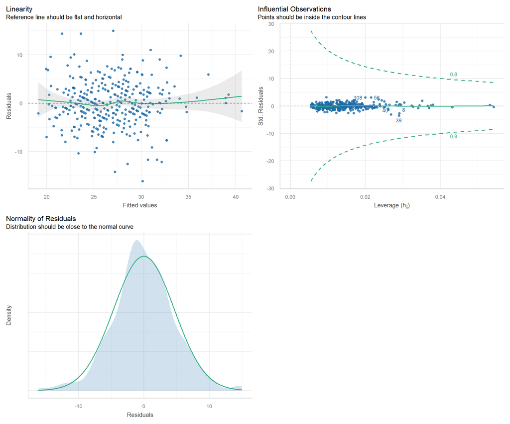

Diagnostic plots for Model 3

```r
# Overall diagnostic plots
# If using R 4.4.x use
performance::check_model(model3,
  check = c(
    "linearity",
    "homoscedasticity",
    "outliers",
    "collinearity",
    "normality"
  )
)
```

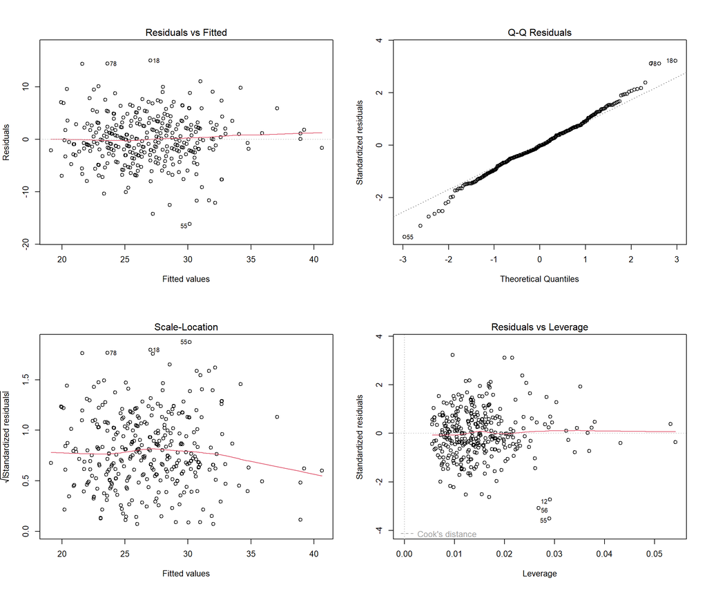

Diagnostic plots for Model 3

```r
# If using R 4.5.x use
# If using R 4.5.x Show all 4 diagnostic plots in one figure using R basic plots
par(mfrow = c(2, 2))   # 2x2 grid layout
plot(model3)            # Generates: Residuals vs Fitted, Normal Q-Q, Scale-Location, Cook’s distance
```

```r
par(mfrow = c(1, 1))    # Reset layout
```

# References

Belsley, D. A., Kuh, E., & Welsch, R. E. (1980). Regression diagnostics: Identifying influential data and sources of collinearity. New York, NY: Wiley.

Field, A., Miles, J., & Field, Z. (2021). Discovering statistics using IBM SPSS Statistics (5th ed.). London, UK: SAGE.

Tabachnick, B. G., & Fidell, L. S. (2019). Using multivariate statistics (7th ed.). Boston, MA: Pearson.